# R Notebook

## Fourier Series

The Fourier series for a periodic function of any period $(T)$ is given by:

$$\begin{aligned}
f(t) = \frac {a_0}{2}+\sum_{i=1}^\infty\{a_n cos(\frac{2n\pi t}{T})+b_n sin(\frac{2n\pi t}{T})\}
\end{aligned}$$

Where $a_n$ and $b_n$ are given by:

$$\begin{array}
{rrr}
a_n = \frac {2}{T} \sum_{\frac {-T}{2}}^\frac{T}{2} f(t)cos(\frac{2n\pi t}{T}) & & & & & & for & n = 0, 1, 2 ...
\end{array}$$

$$\begin{array}
{rrr}
b_n = \frac {2}{T} \sum_{\frac {-T}{2}}^\frac{T}{2} f(t)sin(\frac{2n\pi t}{T}) & & & & & & for & n = 1, 2, 3 ...
\end{array}$$

#### Example 1

A periodic function is given by:

$$\begin{array}
{rrr}
f(t) = \{ & 0 & -2<t<0 & & &f(t+4)=f(t) \\
\{ & t & 0<t<2 & &
\end{array}$$

- Period given is $T=4$
- Limits for this period are $-2<t<2$

This periodic function can be plotted as a piecewise periodic function.

Using *Ft.func* the periodic function can be coded using *ifelse* commands.  
The *Ft.func* can then be plotted using the *plot.piecewise.fnc*.

*plot.piecewise.fnc* inputs:

- *FUN = …* Name given to the peridoic function eg: *Ft.func*
- *.piece.range = …* Limits of the period eg: *c(-2, 2)*
- *.pieces = …* Number of pieces to be included in the piecewise plot eg: *c(-2,-1,0,1)* (4 pieces)
- *.resolution = …* Number of points plotted eg: *101*

```r
library(tidyverse)
```

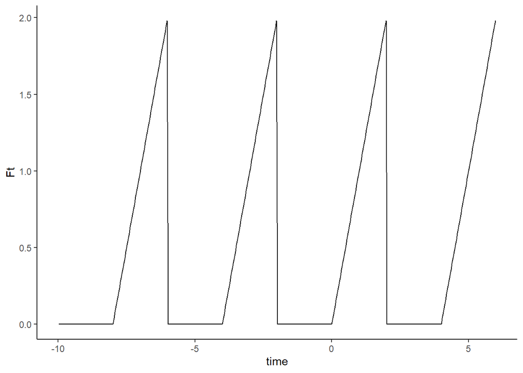

```r
source("scr_functions.R")
Ft.func = function(t){
  ifelse(t<0, 0, t)
}

plot.piecewise.fnc(.FUN = Ft.func, .piece.range = c(-2, 2), .pieces = c(-2,-1,0,1), .resolution = 101)
```

#### Example 2

A periodic function is given by:

$$\begin{array}
{rrr}
f(t) = \{ & t^2 & -3<t<3 & & &f(t+6)=f(t) \\
\end{array}$$

- Period given is $T=6$
- Limits for this period are $-3<t<3$

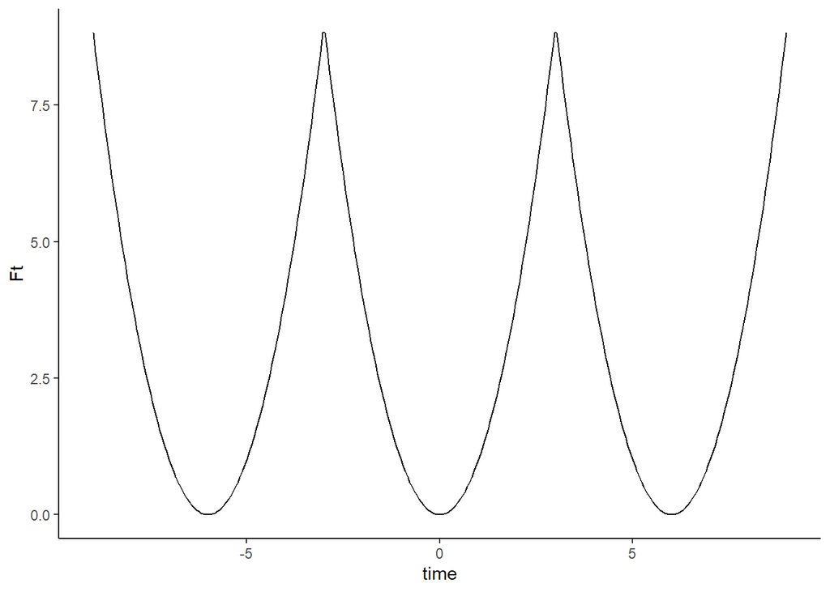

```r
Ft.func2 = function(t){
  t^2
}

plot.piecewise.fnc(.FUN = Ft.func2, .piece.range = c(-3, 3))
```

*** #### Example 3

A periodic function is given by:

$$\begin{array}
{rrr}
f(t) = \{ & -t & -2<t<0 & & &f(t+4)=f(t) \\
\{ & 7 & 0<t<2 & &
\end{array}$$
* Period given is $T=4$
* Limits for this period are $-2<t<2$

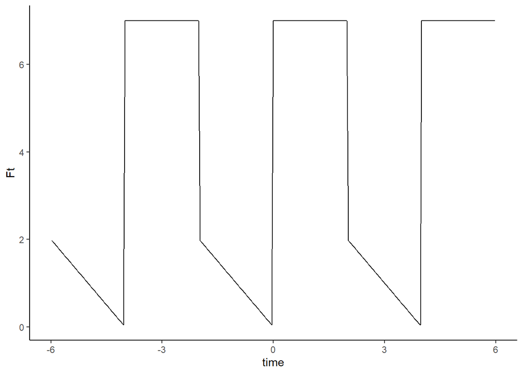

```r
Ft.func3 = function(t){
  ifelse(t<0, -t, 7)
}

plot.piecewise.fnc(.FUN = Ft.func3, .piece.range = c(-2, 2))
```

*** #### Example 4

A periodic function is given by:

$$\begin{array}
{rrr}
f(t) = \{ & -t-3 & -5<t<-3 & & &f(t+13)=f(t) \\
\{ & t+3 & -3<t<0 & & \\
\{ & -2t+3 & 0<t<3 & &\\
\{ & t-6 & 3<t<8 & &
\end{array}$$
* Period given is $T=13$
* Limits for this period are $-5<t<8$

Periodic functions with mulitple definitions for different parts of the domain require more *ifelse* commands.

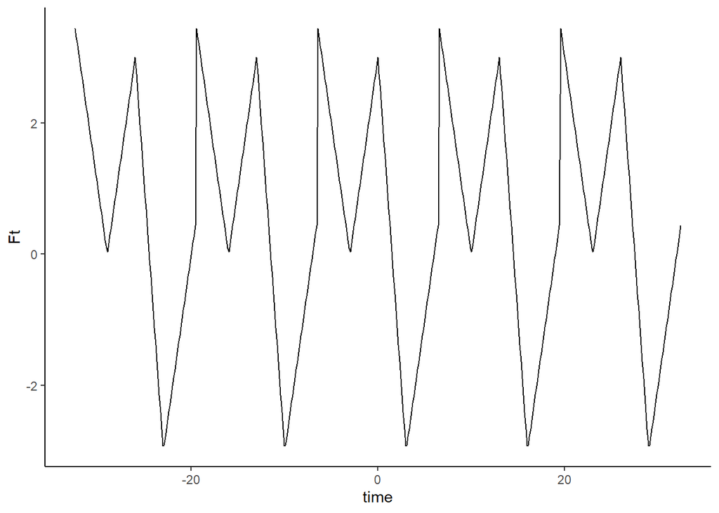

```r
Ft.func4 = function(t){
  ifelse(t<=-3, -t-3,
         ifelse(t>-3 & t<=0, t+3,
                ifelse(t>0 & t<=3, -2*t+3,
                       t-6)))
}

plot.piecewise.fnc(.FUN = Ft.func4, .piece.range = c(-5, 8), .pieces = seq(-2,2))
```

#### Example 5: Functions of period $2\pi$

The Fourier series for a periodic function of period $T=2\pi$ has the general form:

$$\begin{aligned}
f(t) = \frac {a_0}{2}+\sum_{i=1}^\infty\{a_n cos(nt)+ b_n sin(nt)\}
\end{aligned}$$

A piecewise plot for the function $sin(t)$ can be seen:

[figure not shown]

```r
Ft.func5 = function(t){
  sin(t)
}

plot.piecewise.fnc(.FUN = Ft.func5, .piece.range = c(0, 2*pi), .pieces = 0)
```

#### Example 6

A periodic function (*example 1*) is given by:

$$\begin{array}
{rrr}
f(t) = \{ & 0 & -2<t<0 & & &f(t+4)=f(t) \\
\{ & t & 0<t<2 & &
\end{array}$$
This periodic function is plotted as a piecewise periodic function:

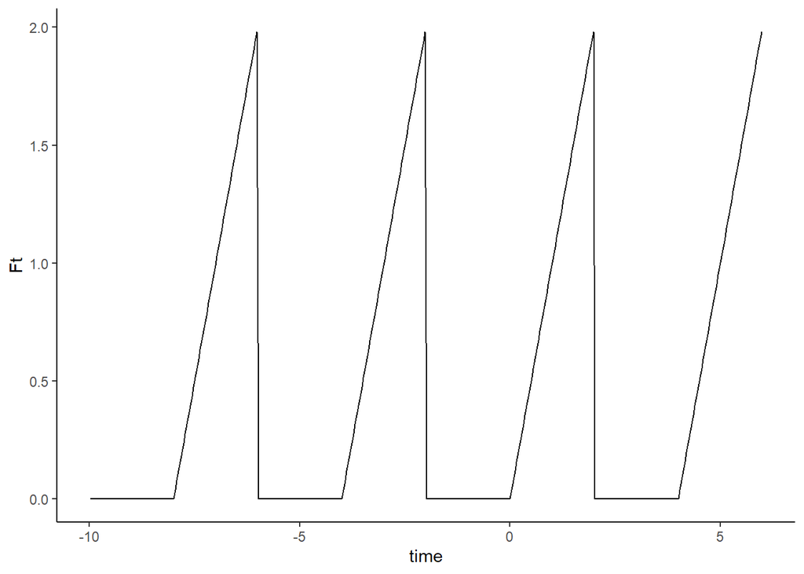

The Fourier Series $f(t)$ including constants $a_0$, $a_n$ and $b_n$ are calculated.

$$\begin{array}
{rrr}
b_n = &\frac{-2}{\pi n} cos(\pi n)&= \frac{-2}{\pi n}(-1)^n&
\end{array}$$

The constants are then coded using using *ifelse* commands.  
The Fourier series can then be plotted using the *plot.fourier.series* function.

[figure not shown]

```r
a0 = 1
an.fn = function(n) {
  ifelse(as.logical(n%%2), -4/(n^2*pi^2), 0)
}

bn.fn = function(n) {
  2/(n*pi) * ifelse(as.logical(n%%2), 1, -1)
}

plot.fourier.series(.T = 4, .a0 = a0, .an.fun = an.fn, .bn.fun = bn.fn,
                    .t.range = c(-10,6), .n.max = 10, .resolution = 300)
```

[output not shown]

Increasing *.n.max* (number of terms in Fourier Series) gives a closer approximation of $f(t)$

*.n.max = 20*

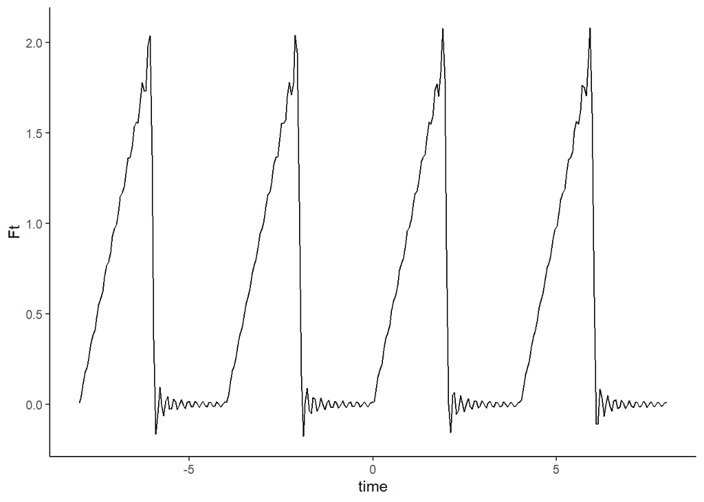

*.n.max = 30*

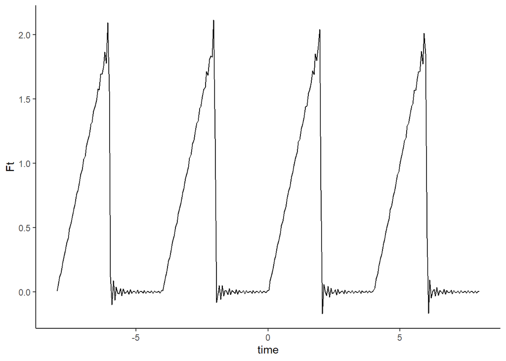